# 1. Title and Student Information

# Predictive Maintenance: Machine Failure Prediction Using Machine Learning

**Student Name:** Ozan Berk Aydin  
**Student Number:** GH1046991  
**Course:** M505 Intro to AI and Machine Learning  
**Submission Date:** June 2026

**Task:** Binary classification  
**Dataset:** Industrial Machine Predictive Maintenance, Kaggle

# 2. Introduction

This project predicts whether a machine will fail within 24 hours using sensor, operating and maintenance features. The target is `failure_within_24h`, so this is a binary classification task.

A useful model can reduce downtime and repair cost by warning maintenance teams before breakdowns happen.

# 3. Data Collection

The Kaggle Industrial Machine Predictive Maintenance dataset was downloaded manually and loaded from `data/predictive_maintenance_v3.csv`.

- Observations: 24,042
- Original variables: 15
- Target: `failure_within_24h`
- Source: https://www.kaggle.com/datasets/tatheerabbas/industrial-machine-predictive-maintenance
- Usage: public Kaggle dataset; no separate local license file was found.
- Project repository for reproducibility: https://github.com/ozanberkaydin/M505_Predictive_Maintenance_Project

The data is suitable because it has mixed feature types, missing values and a non-trivial supervised target.

```python
import pandas as pd
import numpy as np
import matplotlib.pyplot as plt
import seaborn as sns

import warnings
warnings.filterwarnings("ignore")

RANDOM_STATE = 42

raw_data= pd.read_csv("data/predictive_maintenance_v3.csv")
df = raw_data.copy()

df.head()
```

|  | timestamp | machine_id | machine_type | vibration_rms | temperature_motor | current_phase_avg | pressure_level | rpm | operating_mode | hours_since_maintenance | ambient_temp | rul_hours | failure_within_24h | failure_type | estimated_repair_cost |
| --- | --- | --- | --- | --- | --- | --- | --- | --- | --- | --- | --- | --- | --- | --- | --- |
| 0 | 2024-01-01 00:00:00 | 1 | CNC | 0.81 | 49.51 | 5.10 | 23.6 | 860.9 | idle | 273.80 | 13.9 | 61.00 | 0 | none | 0 |
| 1 | 2024-01-01 00:03:00 | 1 | CNC | 0.75 | 40.58 | 5.30 | 23.6 | 899.6 | idle | 273.85 | 10.2 | 60.95 | 0 | none | 0 |
| 2 | 2024-01-01 00:21:00 | 1 | CNC | 0.71 | 49.70 | NaN | 21.3 | 862.7 | idle | 274.15 | 13.6 | 60.65 | 0 | none | 0 |
| 3 | 2024-01-01 00:45:00 | 1 | CNC | 0.76 | 43.04 | 4.79 | 22.6 | 870.4 | idle | 274.55 | 13.4 | 60.25 | 0 | none | 0 |
| 4 | 2024-01-01 00:54:00 | 1 | CNC | 0.88 | 41.39 | 4.44 | 22.2 | 881.9 | idle | 274.70 | 10.8 | 60.10 | 0 | none | 0 |

```python
print(f"Dataset Shape: {df.shape}")
```

```
Dataset Shape: (24042, 15)
```

```python
df.info()
```

```
<class 'pandas.DataFrame'>
RangeIndex: 24042 entries, 0 to 24041
Data columns (total 15 columns):
 #   Column                   Non-Null Count  Dtype
---  ------                   --------------  -----
 0   timestamp                24042 non-null  str
 1   machine_id               24042 non-null  int64
 2   machine_type             24042 non-null  str
 3   vibration_rms            23042 non-null  float64
 4   temperature_motor        23208 non-null  float64
 5   current_phase_avg        23311 non-null  float64
 6   pressure_level           23118 non-null  float64
 7   rpm                      23509 non-null  float64
 8   operating_mode           24042 non-null  str
 9   hours_since_maintenance  24042 non-null  float64
 10  ambient_temp             24042 non-null  float64
 11  rul_hours                24042 non-null  float64
 12  failure_within_24h       24042 non-null  int64
 13  failure_type             24042 non-null  str
 14  estimated_repair_cost    24042 non-null  int64
dtypes: float64(8), int64(3), str(4)
memory usage: 2.8 MB
```

```python
df.describe()
```

|  | machine_id | vibration_rms | temperature_motor | current_phase_avg | pressure_level | rpm | hours_since_maintenance | ambient_temp | rul_hours | failure_within_24h | estimated_repair_cost |
| --- | --- | --- | --- | --- | --- | --- | --- | --- | --- | --- | --- |
| count | 24042.000000 | 23042.000000 | 23208.000000 | 23311.000000 | 23118.000000 | 23509.000000 | 24042.000000 | 24042.000000 | 24042.000000 | 24042.000000 | 24042.000000 |
| mean | 10.505033 | 1.623667 | 51.404295 | 8.823829 | 59.012233 | 1144.849317 | 172.630624 | 12.996398 | 27.812510 | 0.148074 | 608.870144 |
| std | 5.746455 | 1.081061 | 12.519279 | 5.366391 | 38.723271 | 912.670971 | 150.722469 | 2.883994 | 26.393801 | 0.355181 | 1566.793887 |
| min | 1.000000 | 0.350000 | 28.000000 | 2.200000 | 10.100000 | 124.100000 | 0.000000 | 8.000000 | 0.500000 | 0.000000 | 0.000000 |
| 25% | 6.000000 | 0.820000 | 42.610000 | 4.630000 | 22.700000 | 489.400000 | 42.870000 | 10.500000 | 0.500000 | 0.000000 | 0.000000 |
| 50% | 10.000000 | 1.270000 | 50.060000 | 6.430000 | 46.300000 | 856.000000 | 121.610000 | 13.000000 | 22.570000 | 0.000000 | 0.000000 |
| 75% | 15.000000 | 2.270000 | 59.962500 | 13.120000 | 94.700000 | 1676.000000 | 295.575000 | 15.500000 | 46.410000 | 0.000000 | 0.000000 |
| max | 20.000000 | 10.000000 | 95.000000 | 35.000000 | 206.500000 | 4098.800000 | 575.630000 | 18.000000 | 98.340000 | 1.000000 | 7995.000000 |

```python
df.columns
```

```
Index(['timestamp', 'machine_id', 'machine_type', 'vibration_rms',
       'temperature_motor', 'current_phase_avg', 'pressure_level', 'rpm',
       'operating_mode', 'hours_since_maintenance', 'ambient_temp',
       'rul_hours', 'failure_within_24h', 'failure_type',
       'estimated_repair_cost'],
      dtype='str')
```

```python
df.isnull().sum()
```

```
timestamp                     0
machine_id                    0
machine_type                  0
vibration_rms              1000
temperature_motor           834
current_phase_avg           731
pressure_level              924
rpm                         533
operating_mode                0
hours_since_maintenance       0
ambient_temp                  0
rul_hours                     0
failure_within_24h            0
failure_type                  0
estimated_repair_cost         0
dtype: int64
```

# 4. Exploratory Data Analysis

### Initial Observations

The dataset has 24,042 rows and 15 variables. Several sensor fields have missing values, and both numerical and categorical features need preprocessing.

```python
df.duplicated().sum()
```

```
np.int64(0)
```

```python
df["failure_within_24h"].value_counts()
```

```
failure_within_24h
0    20482
1     3560
Name: count, dtype: int64
```

```python
df["failure_within_24h"].value_counts(normalize=True) * 100
```

```
failure_within_24h
0    85.19258
1    14.80742
Name: proportion, dtype: float64
```

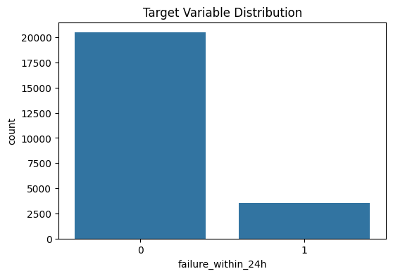

```python
plt.figure(figsize=(6,4))
sns.countplot(data=df, x="failure_within_24h")
plt.title("Target Variable Distribution")
plt.show()
```

The target is moderately imbalanced: about 85% normal observations and 15% failures within 24 hours. Therefore, F1-score, precision, recall and ROC-AUC are more informative than accuracy alone.

Categorical failure rates are checked for machine type and operating mode.

```
Failure rate by machine_type:
machine_type
Compressor     0.159987
Pump           0.149329
Robotic Arm    0.142429
CNC            0.140475
Name: failure_within_24h, dtype: float64
```

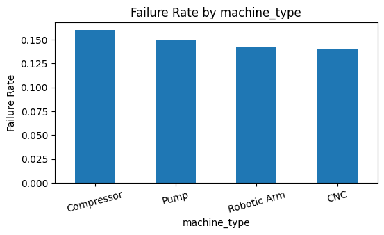

```
Failure rate by operating_mode:
operating_mode
peak      0.160207
normal    0.149415
idle      0.144909
Name: failure_within_24h, dtype: float64
```

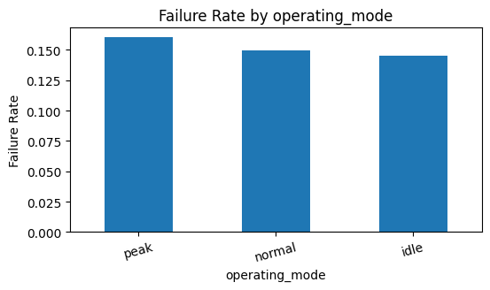

```python
for cat in ["machine_type", "operating_mode"]:
    rates = df.groupby(cat)["failure_within_24h"].mean().sort_values(ascending=False)
    print(f"Failure rate by {cat}:")
    print(rates)
    plt.figure(figsize=(6,3))
    rates.plot(kind="bar")
    plt.title(f"Failure Rate by {cat}")
    plt.ylabel("Failure Rate")
    plt.xticks(rotation=15)
    plt.show()
```

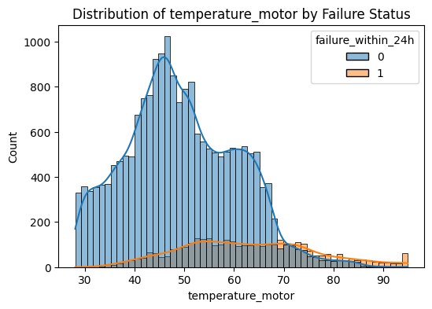

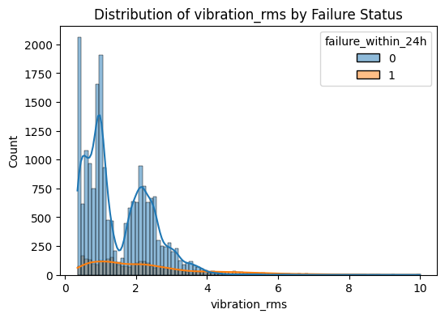

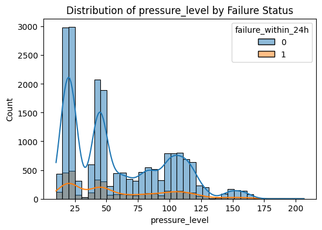

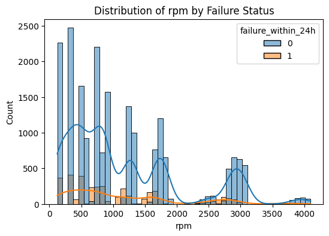

```python
selected_features = [
    "temperature_motor",
    "vibration_rms",
    "pressure_level",
    "rpm"
]

for feature in selected_features:
    plt.figure(figsize=(6,4))

    sns.histplot(
        data=df,
        x=feature,
        hue="failure_within_24h",
        kde=True
    )

    plt.title(f"Distribution of {feature} by Failure Status")
    plt.xlabel(feature)
    plt.ylabel("Count")

    plt.show()
```

### Feature Distributions

Failure cases tend to have higher motor temperature and vibration values. This supports keeping sensor variables as predictors.

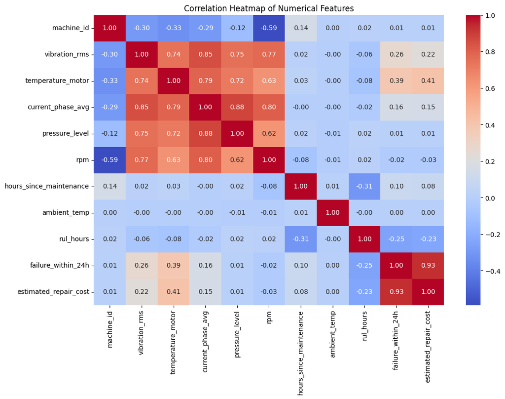

```python
numeric_df = df.select_dtypes(include=["int64", "float64"])

plt.figure(figsize=(12,8))

sns.heatmap(
    numeric_df.corr(),
    annot=True,
    fmt=".2f",
    cmap="coolwarm"
)

plt.title("Correlation Heatmap of Numerical Features")

plt.show()
```

### Correlation Analysis

`estimated_repair_cost` is highly correlated with the target, but it is removed before training because it is only known after failure. Among usable operational variables, temperature and vibration show clear positive relationships with failure risk.

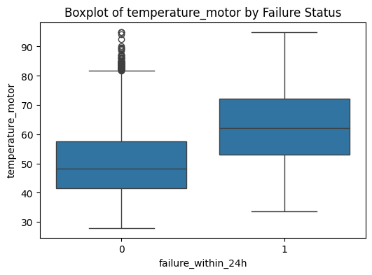

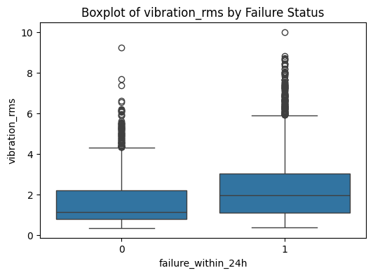

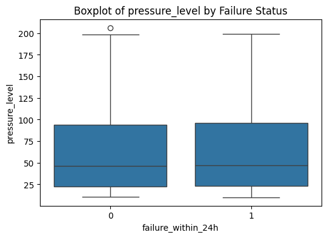

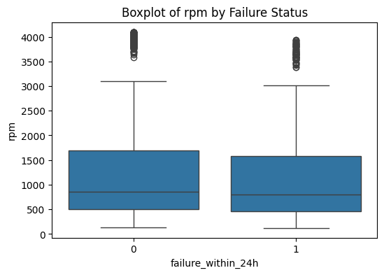

```python
selected_features = [
    "temperature_motor",
    "vibration_rms",
    "pressure_level",
    "rpm"
]

for feature in selected_features:

    plt.figure(figsize=(6,4))

    sns.boxplot(
        data=df,
        x="failure_within_24h",
        y=feature
    )

    plt.title(f"Boxplot of {feature} by Failure Status")

    plt.show()
```

### Outlier Analysis

Boxplots show outliers in vibration, temperature and RPM. In predictive maintenance these may represent abnormal operating states, so they are retained rather than removed automatically.

### Missing Values

Missing sensor values are handled inside the pipeline using imputation. This avoids dropping useful rows and reduces leakage risk.

```python
missing_values = df.isnull().sum().sort_values(ascending=False)
missing_values[missing_values > 0]
```

```
vibration_rms        1000
pressure_level        924
temperature_motor     834
current_phase_avg     731
rpm                   533
dtype: int64
```

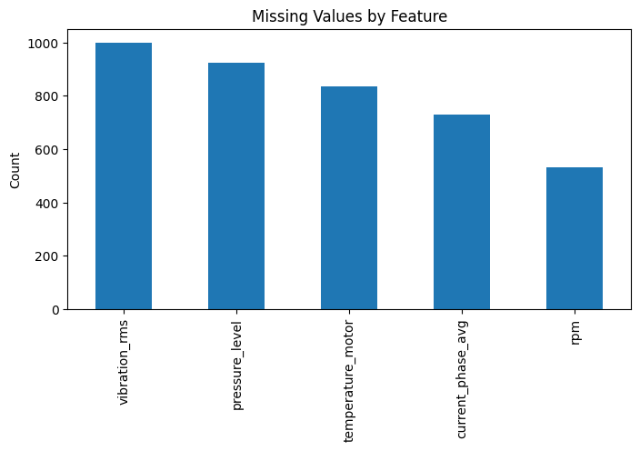

```python
plt.figure(figsize=(8,4))

missing_values[missing_values > 0].plot(kind="bar")

plt.title("Missing Values by Feature")
plt.ylabel("Count")
plt.show()
```

# 5. Data Cleaning and Feature Engineering

Before modelling, leakage fields are removed, missing values are imputed, categorical variables are one-hot encoded and numerical variables are scaled when needed.

```python
X = df.drop(
    [
        "failure_within_24h",
        "failure_type",
        "estimated_repair_cost",
        "timestamp",
        "rul_hours"
    ],
    axis=1
)

y = df["failure_within_24h"]
```

### Target Leakage Prevention

`failure_type`, `estimated_repair_cost` and `rul_hours` were removed because they contain information that would not be available before a failure decision. Keeping them produced unrealistically perfect scores.

```python
X["machine_id"] = X["machine_id"].astype(str)
```

```python
numeric_features = X.select_dtypes(
    include=["int64", "float64"]
).columns.tolist()

categorical_features = X.select_dtypes(
    include=["object"]
).columns.tolist()

print("Numerical Features:")
print(numeric_features)

print("\nCategorical Features:")
print(categorical_features)
```

```
Numerical Features:
['vibration_rms', 'temperature_motor', 'current_phase_avg', 'pressure_level', 'rpm', 'hours_since_maintenance', 'ambient_temp']

Categorical Features:
['machine_id', 'machine_type', 'operating_mode']
```

```python
df["machine_id"].nunique()
```

```
20
```

### Feature Selection Decision

`machine_id` has 20 identifiers. It is kept as a categorical feature because repeated observations may capture machine-specific risk patterns without imposing an artificial numeric order.

```python
df["machine_id"].head()
```

```
0    1
1    1
2    1
3    1
4    1
Name: machine_id, dtype: int64
```

```python
from sklearn.model_selection import train_test_split

X_train, X_test, y_train, y_test = train_test_split(
    X,
    y,
    test_size=0.20,
    random_state=RANDOM_STATE,
    stratify=y
)

print(X_train.shape)
print(X_test.shape)
```

```
(19233, 10)
(4809, 10)
```

### Train-Test Split

An 80/20 train-test split is used with `random_state=42`. Stratification preserves the failure rate in both sets, which is important for the imbalanced target.

### Preprocessing Pipeline

```python
from sklearn.impute import SimpleImputer
from sklearn.preprocessing import StandardScaler, OneHotEncoder
from sklearn.feature_selection import SelectKBest, f_classif
from sklearn.pipeline import Pipeline
from sklearn.compose import ColumnTransformer
from sklearn.linear_model import LogisticRegression
from sklearn.tree import DecisionTreeClassifier
from sklearn.ensemble import RandomForestClassifier, GradientBoostingClassifier
from sklearn.model_selection import cross_val_score, GridSearchCV
from sklearn.metrics import accuracy_score, precision_score, recall_score, f1_score, roc_auc_score
```

```python
numeric_pipeline = Pipeline(
    steps=[
        ("imputer", SimpleImputer(strategy="median")),
        ("scaler", StandardScaler())
    ]
)
```

```python
categorical_pipeline = Pipeline(
    steps=[
        ("imputer", SimpleImputer(strategy="most_frequent")),
        ("encoder", OneHotEncoder(handle_unknown="ignore"))
    ]
)
```

Numerical features use median imputation and `StandardScaler`. Categorical features use most-frequent imputation and `OneHotEncoder`. `ColumnTransformer` keeps preprocessing inside the training pipeline, improving reproducibility and reducing leakage.

```python
preprocessor = ColumnTransformer(
    transformers=[
        ("num", numeric_pipeline, numeric_features),
        ("cat", categorical_pipeline, categorical_features)
    ]
)
```

# 6. Data Engineering Comparison

Three LR strategies are compared: A imputation+encoding, B A+scaling, C B+`SelectKBest`.

```python
numeric_pipeline_a = Pipeline([
    ("imputer", SimpleImputer(strategy="median"))
])

categorical_pipeline_a = Pipeline([
    ("imputer", SimpleImputer(strategy="most_frequent")),
    ("encoder", OneHotEncoder(handle_unknown="ignore"))
])

preprocessor_a = ColumnTransformer([
    ("num", numeric_pipeline_a, numeric_features),
    ("cat", categorical_pipeline_a, categorical_features)
])

pipeline_a = Pipeline([
    ("preprocessor", preprocessor_a),
    ("model", LogisticRegression(max_iter=1000, random_state=RANDOM_STATE))
])

pipeline_b = Pipeline([
    ("preprocessor", preprocessor),
    ("model", LogisticRegression(max_iter=1000, random_state=RANDOM_STATE))
])

pipeline_c = Pipeline([
    ("preprocessor", preprocessor),
    ("selector", SelectKBest(score_func=f_classif, k=10)),
    ("model", LogisticRegression(max_iter=1000, random_state=RANDOM_STATE))
])

engineering_pipelines = {
    "A: No Scaling": pipeline_a,
    "B: Scaling": pipeline_b,
    "C: Scaling + SelectKBest": pipeline_c
}

engineering_results = []
for name, pipe in engineering_pipelines.items():
    pipe.fit(X_train, y_train)
    pred = pipe.predict(X_test)
    engineering_results.append({"Strategy": name, "F1 Score": f1_score(y_test, pred)})

comparison_df = pd.DataFrame(engineering_results)
comparison_df
```

|  | Strategy | F1 Score |
| --- | --- | --- |
| 0 | A: No Scaling | 0.740684 |
| 1 | B: Scaling | 0.764618 |
| 2 | C: Scaling + SelectKBest | 0.462273 |

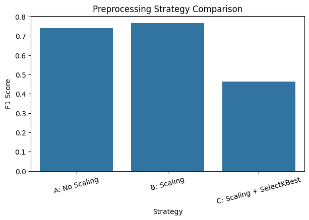

```python
plt.figure(figsize=(7,4))
sns.barplot(data=comparison_df, x="Strategy", y="F1 Score")
plt.title("Preprocessing Strategy Comparison")
plt.xticks(rotation=15)
plt.show()
```

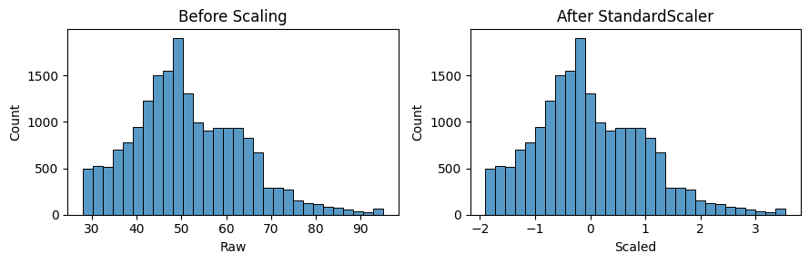

```python
feature_to_scale = "temperature_motor"
raw_feature = X_train[[feature_to_scale]]
imputed = SimpleImputer(strategy="median").fit_transform(raw_feature)
scaled = StandardScaler().fit_transform(imputed)
scaling_demo_df = pd.DataFrame({
    "Raw": imputed.ravel(),
    "Scaled": scaled.ravel()
})

fig, axes = plt.subplots(1, 2, figsize=(9,3))
sns.histplot(scaling_demo_df["Raw"], ax=axes[0], bins=30)
axes[0].set_title("Before Scaling")
sns.histplot(scaling_demo_df["Scaled"], ax=axes[1], bins=30)
axes[1].set_title("After StandardScaler")
plt.tight_layout()
plt.show()
```

### Data Engineering Results

Scaling improved LR F1 from 0.741 to 0.765. `SelectKBest` reduced F1 to 0.462, so feature selection removed useful signals and was not selected.

# 7. Model Training

```python
models = {
    "Logistic Regression": LogisticRegression(max_iter=1000, random_state=RANDOM_STATE),
    "Decision Tree": DecisionTreeClassifier(random_state=RANDOM_STATE),
    "Random Forest": RandomForestClassifier(random_state=RANDOM_STATE),
    "Gradient Boosting": GradientBoostingClassifier(random_state=RANDOM_STATE)
}
```

```python
model_results = []

for model_name, model in models.items():
    model_pipeline = Pipeline([
        ("preprocessor", preprocessor),
        ("model", model)
    ])

    cv_scores = cross_val_score(
        model_pipeline,
        X_train,
        y_train,
        cv=5,
        scoring="f1",
        n_jobs=1
    )

    model_pipeline.fit(X_train, y_train)
    y_pred = model_pipeline.predict(X_test)
    y_proba = model_pipeline.predict_proba(X_test)[:, 1]

    model_results.append({
        "Model": model_name,
        "CV F1 Mean": cv_scores.mean(),
        "CV F1 Std": cv_scores.std(),
        "Accuracy": accuracy_score(y_test, y_pred),
        "Precision": precision_score(y_test, y_pred),
        "Recall": recall_score(y_test, y_pred),
        "F1 Score": f1_score(y_test, y_pred),
        "ROC-AUC": roc_auc_score(y_test, y_proba)
    })

model_results_df = pd.DataFrame(model_results)
model_results_df.sort_values(by="F1 Score", ascending=False)
```

|  | Model | CV F1 Mean | CV F1 Std | Accuracy | Precision | Recall | F1 Score | ROC-AUC |
| --- | --- | --- | --- | --- | --- | --- | --- | --- |
| 2 | Random Forest | 0.919785 | 0.005900 | 0.973383 | 0.912429 | 0.907303 | 0.909859 | 0.995917 |
| 1 | Decision Tree | 0.845499 | 0.006679 | 0.954668 | 0.844011 | 0.851124 | 0.847552 | 0.911893 |
| 3 | Gradient Boosting | 0.835211 | 0.005797 | 0.951549 | 0.862330 | 0.800562 | 0.830299 | 0.981871 |
| 0 | Logistic Regression | 0.754307 | 0.011423 | 0.934706 | 0.819936 | 0.716292 | 0.764618 | 0.963600 |

### Initial Model Comparison

Models use 5-fold CV plus held-out test scores. Random Forest performs best.

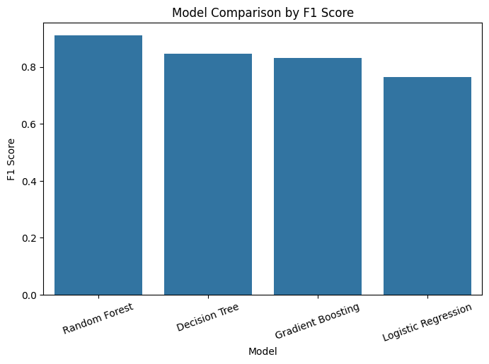

```python
plt.figure(figsize=(8,5))

sns.barplot(
    data=model_results_df.sort_values(
        by="F1 Score",
        ascending=False
    ),
    x="Model",
    y="F1 Score"
)

plt.title("Model Comparison by F1 Score")
plt.xticks(rotation=20)

plt.show()
```

F1 is the main metric because failures are the minority class.

# 8. Hyperparameter Tuning

Grid search tunes LR (`C`, `penalty`, `solver`) and RF (`n_estimators`, depth, split size, `max_features`).

```python
rf_pipeline = Pipeline(
    steps=[
        ("preprocessor", preprocessor),
        ("model", RandomForestClassifier(random_state=RANDOM_STATE))
    ]
)
```

```python
param_grid = {
    "model__n_estimators": [100, 200],
    "model__max_depth": [10, None],
    "model__min_samples_split": [2, 5],
    "model__max_features": ["sqrt", "log2"]
}
```

```python
lr_pipeline = Pipeline([
    ("preprocessor", preprocessor),
    ("model", LogisticRegression(max_iter=1000, random_state=RANDOM_STATE))
])

lr_param_grid = {
    "model__C": [0.01, 0.1, 1, 10, 100],
    "model__penalty": ["l2"],
    "model__solver": ["lbfgs", "liblinear"]
}

lr_grid_search = GridSearchCV(
    estimator=lr_pipeline,
    param_grid=lr_param_grid,
    cv=5,
    scoring="f1",
    n_jobs=1
)

_ = lr_grid_search.fit(X_train, y_train)

print("Best Parameters:")
print(lr_grid_search.best_params_)
print("Best F1 Score:")
print(lr_grid_search.best_score_)
```

```
Best Parameters:
{'model__C': 100, 'model__penalty': 'l2', 'model__solver': 'liblinear'}
Best F1 Score:
0.7567764722840998
```

### Logistic Regression Hyperparameter Tuning

`C` controls regularisation strength, while `solver` changes the optimisation method. The grid checks whether weaker regularisation improves recall without overfitting.

```python
grid_search = GridSearchCV(
    estimator=rf_pipeline,
    param_grid=param_grid,
    cv=5,
    scoring="f1",
    n_jobs=1
)

_ = grid_search.fit(X_train, y_train)
```

```python
print("Best Parameters:")
print(grid_search.best_params_)

print("\nBest F1 Score:")
print(grid_search.best_score_)
```

```
Best Parameters:
{'model__max_depth': None, 'model__max_features': 'sqrt', 'model__min_samples_split': 2, 'model__n_estimators': 200}

Best F1 Score:
0.91983869978633
```

```python
best_rf = grid_search.best_estimator_

y_pred_tuned = best_rf.predict(X_test)
y_proba_tuned = best_rf.predict_proba(X_test)[:, 1]

final_metrics = {
    "Accuracy": accuracy_score(y_test, y_pred_tuned),
    "Precision": precision_score(y_test, y_pred_tuned),
    "Recall": recall_score(y_test, y_pred_tuned),
    "F1 Score": f1_score(y_test, y_pred_tuned),
    "ROC-AUC": roc_auc_score(y_test, y_proba_tuned)
}

final_metrics_df = pd.DataFrame([final_metrics])
final_metrics_df
```

|  | Accuracy | Precision | Recall | F1 Score | ROC-AUC |
| --- | --- | --- | --- | --- | --- |
| 0 | 0.974631 | 0.922636 | 0.904494 | 0.913475 | 0.996044 |

```python
best_rf_model = grid_search.best_estimator_

feature_names = best_rf_model.named_steps["preprocessor"].get_feature_names_out()

importances = best_rf_model.named_steps["model"].feature_importances_

feature_importance_df = pd.DataFrame({
    "Feature": feature_names,
    "Importance": importances
}).sort_values(by="Importance", ascending=False)

feature_importance_df.head(15)
```

|  | Feature | Importance |
| --- | --- | --- |
| 1 | num__temperature_motor | 0.215148 |
| 4 | num__rpm | 0.167214 |
| 0 | num__vibration_rms | 0.156016 |
| 2 | num__current_phase_avg | 0.133192 |
| 5 | num__hours_since_maintenance | 0.115882 |
| 3 | num__pressure_level | 0.058305 |
| 6 | num__ambient_temp | 0.025773 |
| 32 | cat__operating_mode_normal | 0.019754 |
| 33 | cat__operating_mode_peak | 0.017770 |
| 31 | cat__operating_mode_idle | 0.010531 |
| 29 | cat__machine_type_Pump | 0.007734 |
| 30 | cat__machine_type_Robotic Arm | 0.005976 |
| 8 | cat__machine_id_10 | 0.005424 |
| 27 | cat__machine_type_CNC | 0.005263 |
| 28 | cat__machine_type_Compressor | 0.005204 |

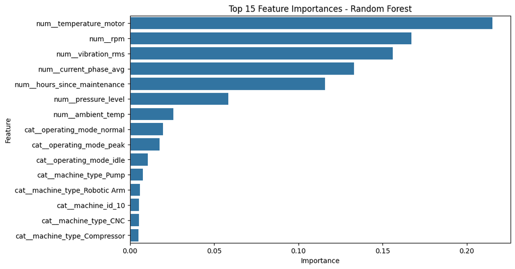

```python
plt.figure(figsize=(10,6))

sns.barplot(
    data=feature_importance_df.head(15),
    x="Importance",
    y="Feature"
)

plt.title("Top 15 Feature Importances - Random Forest")
plt.xlabel("Importance")
plt.ylabel("Feature")

plt.show()
```

### Feature Importance Analysis

Random Forest feature importances improve explainability. The strongest predictors are operational sensor variables such as motor temperature, RPM, vibration, current, maintenance history and pressure.

### Hyperparameter Tuning Results

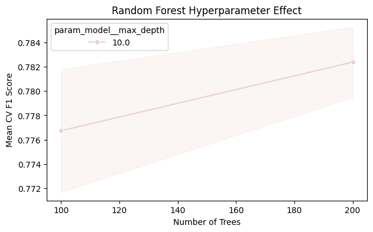

```python
cv_results = pd.DataFrame(grid_search.cv_results_)

plt.figure(figsize=(7,4))
sns.lineplot(
    data=cv_results,
    x="param_model__n_estimators",
    y="mean_test_score",
    hue="param_model__max_depth",
    marker="o"
)
plt.title("Random Forest Hyperparameter Effect")
plt.ylabel("Mean CV F1 Score")
plt.xlabel("Number of Trees")
plt.show()
```

RF selected 200 trees, no depth limit, split size 2 and `max_features='sqrt'`. This gave CV F1 = 0.920 and test F1 = 0.913.

### Class Imbalance Check

Because failures are only about 15% of the data, a balanced Logistic Regression baseline is tested against the regular model.

```python
balanced_lr = Pipeline([
    ("preprocessor", preprocessor),
    ("model", LogisticRegression(
        max_iter=1000,
        class_weight="balanced",
        random_state=RANDOM_STATE
    ))
])

balanced_lr.fit(X_train, y_train)
balanced_pred = balanced_lr.predict(X_test)

imbalance_df = pd.DataFrame([
    {"Model": "Logistic Regression", "F1 Score": f1_score(y_test, pipeline_b.predict(X_test))},
    {"Model": "Balanced Logistic Regression", "F1 Score": f1_score(y_test, balanced_pred)}
])
imbalance_df
```

|  | Model | F1 Score |
| --- | --- | --- |
| 0 | Logistic Regression | 0.764618 |
| 1 | Balanced Logistic Regression | 0.760186 |

The balanced LR test gave F1 = 0.760 versus 0.765 for regular LR, so class weighting did not improve this dataset. RF remains the final model.

### Loss Function Curve

Gradient Boosting training loss is plotted by boosting stage to directly show optimisation behaviour.

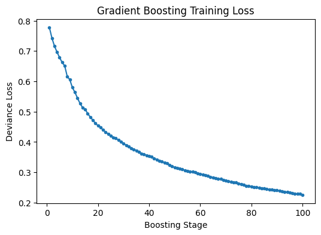

```python
gbm_loss_pipeline = Pipeline([
    ("preprocessor", preprocessor),
    ("model", GradientBoostingClassifier(random_state=RANDOM_STATE))
])

gbm_loss_pipeline.fit(X_train, y_train)
train_loss = gbm_loss_pipeline.named_steps["model"].train_score_

plt.figure(figsize=(6,4))
plt.plot(range(1, len(train_loss) + 1), train_loss, marker="o", markersize=3)
plt.title("Gradient Boosting Training Loss")
plt.xlabel("Boosting Stage")
plt.ylabel("Deviance Loss")
plt.show()
```

The loss decreases and then flattens, so later boosting stages add limited extra improvement. This supports using validation metrics, not training loss alone, for final model choice.

# 9. Final Model Evaluation

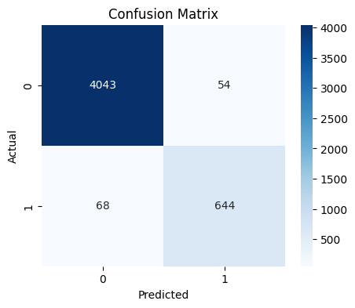

```
False negatives: 68
False positives: 54
```

```python
from sklearn.metrics import confusion_matrix

cm = confusion_matrix(y_test, y_pred_tuned)

plt.figure(figsize=(5,4))
sns.heatmap(cm, annot=True, fmt="d", cmap="Blues")
plt.title("Confusion Matrix")
plt.xlabel("Predicted")
plt.ylabel("Actual")
plt.show()

false_negatives = cm[1, 0]
false_positives = cm[0, 1]
print("False negatives:", false_negatives)
print("False positives:", false_positives)
```

### Confusion Matrix Interpretation

The tuned Random Forest correctly identifies most normal and failure cases. The remaining errors are important in business terms: false negatives mean missed failures, while false positives mean unnecessary maintenance checks.

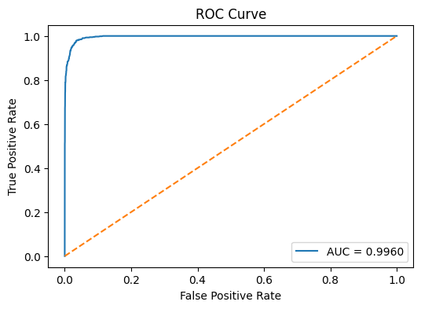

```python
from sklearn.metrics import roc_curve

fpr, tpr, thresholds = roc_curve(y_test, y_proba_tuned)

plt.figure(figsize=(6,4))
plt.plot(fpr, tpr, label=f"AUC = {final_metrics['ROC-AUC']:.4f}")
plt.plot([0,1], [0,1], linestyle="--")
plt.xlabel("False Positive Rate")
plt.ylabel("True Positive Rate")
plt.title("ROC Curve")
plt.legend()
plt.show()
```

### ROC Curve Interpretation

The ROC curve is close to the upper-left corner and the AUC is high, showing strong separation between failure and non-failure observations.

# 10. Conclusion

The final Random Forest is the strongest model, with test F1 = 0.913 and ROC-AUC = 0.996 after leakage prevention, preprocessing comparison, 5-fold CV, imbalance checking and tuning.

The most informative features are temperature, RPM, vibration, current and hours since maintenance. These results fit the business problem: machines under thermal, mechanical or maintenance stress are more likely to fail.

### Limitations

The analysis uses one public, highly structured dataset, so real production performance may be lower. Random splitting can also place different time records from the same machine in both train and test sets, which may overestimate generalisation. False negatives remain the most serious risk because they represent missed failures.

### Future Work

Before deployment, I would pilot the model on recent company data, compare predictions with maintenance logs, monitor false negatives, drift and calibration, and keep human review for high-risk alerts. Future validation should use time-based or machine-based splits to test generalisation more realistically.

# 11. References

Kaggle. (2025). Industrial Machine Predictive Maintenance Dataset. Available at: https://www.kaggle.com/datasets/tatheerabbas/industrial-machine-predictive-maintenance

Pedregosa, F. et al. (2011). Scikit-learn: Machine Learning in Python. Journal of Machine Learning Research, 12, pp. 2825-2830.

McKinney, W. (2022). Python for Data Analysis. 3rd ed. O'Reilly Media.

Hunter, J.D. (2007). Matplotlib: A 2D Graphics Environment. Computing in Science & Engineering, 9(3), pp. 90-95.